# A solution that fits in your pocket, yet millions of children never receive it

Author

Marie Blanc-Coquand

Published

April 10, 2026

# Access to Oral Rehydration Therapy: a global analysis

**Oral Rehydration Therapy (ORT)** is a precise mix of water, salt and sugar. It costs less than **$0.37** and is considered one of the most significant medical innovations of the twentieth century.

And yet, across **116 countries**, fewer than **1 in 2 children** with diarrhoea receives it.

This report explores **where** ORT does not reach, **how** coverage has evolved, and **what** may predict access to this life-saving treatment.

## Where does ORT not reach?

Access to Oral Rehydration Therapy remains highly uneven across the world, revealing **strong geographical disparities**.

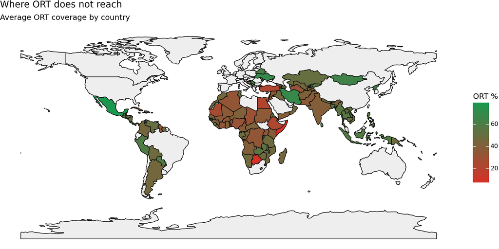

```python
import geopandas as gpd

# Moyenne ORT par pays sur toute la période
ort_country = df.group_by(["country", "alpha_3_code"]).agg(pl.col("ort").mean()).to_pandas()

# Charger les frontières mondiales
world = gpd.read_file("https://naturalearth.s3.amazonaws.com/110m_cultural/ne_110m_admin_0_countries.zip")
wm = world.merge(ort_country, left_on="ADM0_A3", right_on="alpha_3_code", how="left")

(ggplot(wm)
 + geom_map(aes(fill="ort"))
 + scale_fill_gradient(low="#d73027", high="#1a9850", na_value="#eeeeee", name="ORT %")
 + labs(title="Where ORT does not reach", subtitle="Average ORT coverage by country")
 + theme_void()
 + theme(figure_size=(10, 5)))
```

## 20 years of slow progress

ORT coverage has stayed almost flat at around **46%** for more than 20 years. Even in the best year, 2019 (56.65%), the improvement did not last.

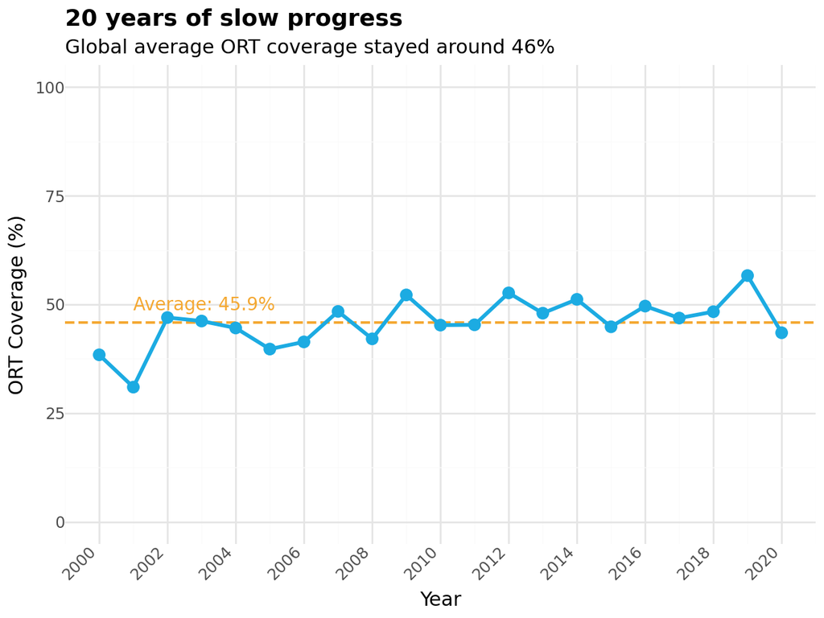

Figure 1: Global average ORT coverage 2000–2020

## Better ORT → longer lives

ORT is not just a treatment for diarrhoea: it is a marker of how well a health system reaches its most vulnerable.

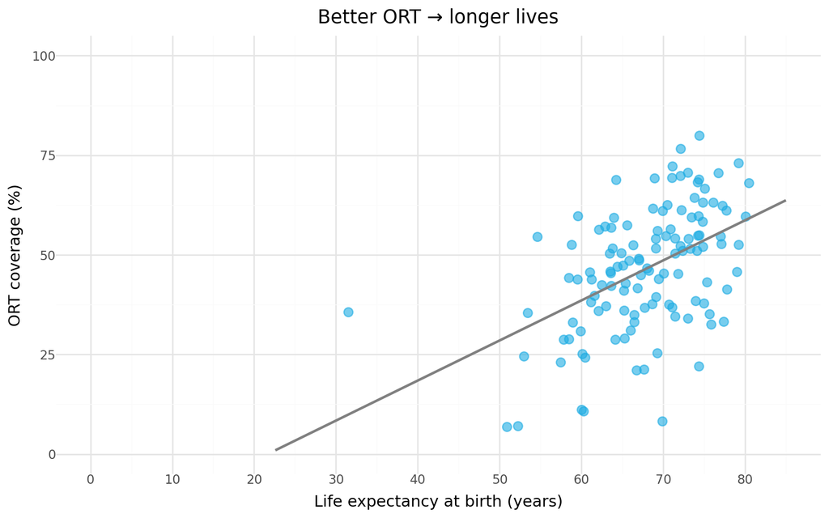

## The countries leading the way

These 15 countries show that high ORT coverage is not only achieved by wealthy nations. Several **low and middle income countries** rank among the best performers, suggesting that **targeted health programmes** can make a real difference

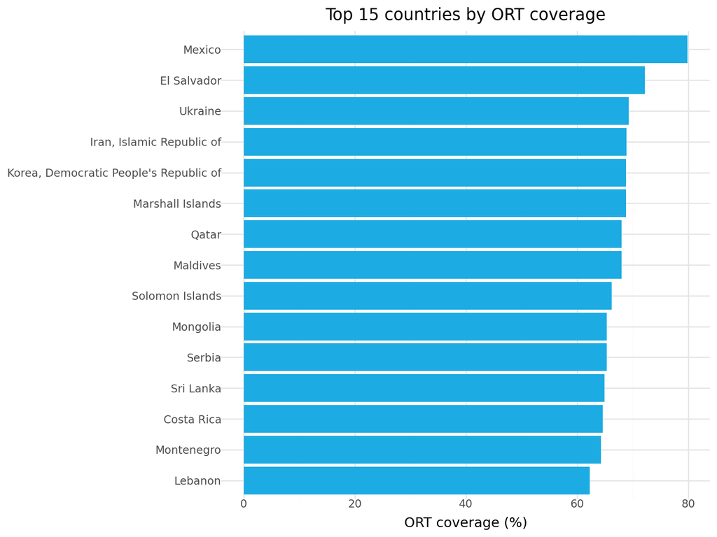

```python
top15 = ort_country.nlargest(15, "ort")

(ggplot(top15, aes(x="reorder(country, ort)", y="ort"))
 + geom_col(fill="#1cabe2")
 + coord_flip()
 + labs(title="Top 15 countries by ORT coverage", x="", y="ORT coverage (%)")
 + theme_minimal()
 + theme(figure_size=(8, 6)))
```

## The takeaway

> *444,000 children under 5 die every year from diarrhoea.* — UNICEF, 2024

*Data source: UNICEF · Visualisation by Marie Blanc-Coquand · BAA1030 — Dublin City University*